# Ground-Dwelling Natural Enemy Abundance and Diversity in Relation to Local Management and Landscape Heterogeneity in Okanagan Vineyards

#### 8.2.3 Carabid abundance

```r
# full model (both years)
carabid_abund_poisson <- glmmTMB(
  carabid_abundance ~
    z_veg_height + z_veg_cover + z_veg_richness +
    z_total_natural_500 + z_distance_natural + year +
    (1 | site_ID) +
    offset(log(trap_count)),
  data = carabid_df_clean,
  family = poisson
)
summary(carabid_abund_poisson)
```

```
##  Family: poisson  ( log )
## Formula:
## carabid_abundance ~ z_veg_height + z_veg_cover + z_veg_richness +
##     z_total_natural_500 + z_distance_natural + year + (1 | site_ID) +
##     offset(log(trap_count))
## Data: carabid_df_clean
##
##       AIC       BIC    logLik -2*log(L)  df.resid
##     896.3     918.3    -440.1     880.3       108
##
## Random effects:
##
## Conditional model:
##  Groups  Name        Variance Std.Dev.
##  site_ID (Intercept) 0.6493   0.8058
## Number of obs: 116, groups:  site_ID, 37
##
## Conditional model:
##                     Estimate Std. Error z value Pr(>|z|)
## (Intercept)          0.52223    0.15713   3.324 0.000889 ***
## z_veg_height         0.22885    0.05033   4.547 5.44e-06 ***
## z_veg_cover         -0.08354    0.05550  -1.505 0.132243
## z_veg_richness       0.09505    0.05477   1.735 0.082689 .
## z_total_natural_500 -0.03500    0.16384  -0.214 0.830817
## z_distance_natural   0.15401    0.17292   0.891 0.373121
## year2025             0.48222    0.09595   5.026 5.01e-07 ***
## ---
## Signif. codes:  0 '***' 0.001 '**' 0.01 '*' 0.05 '.' 0.1 ' ' 1
```

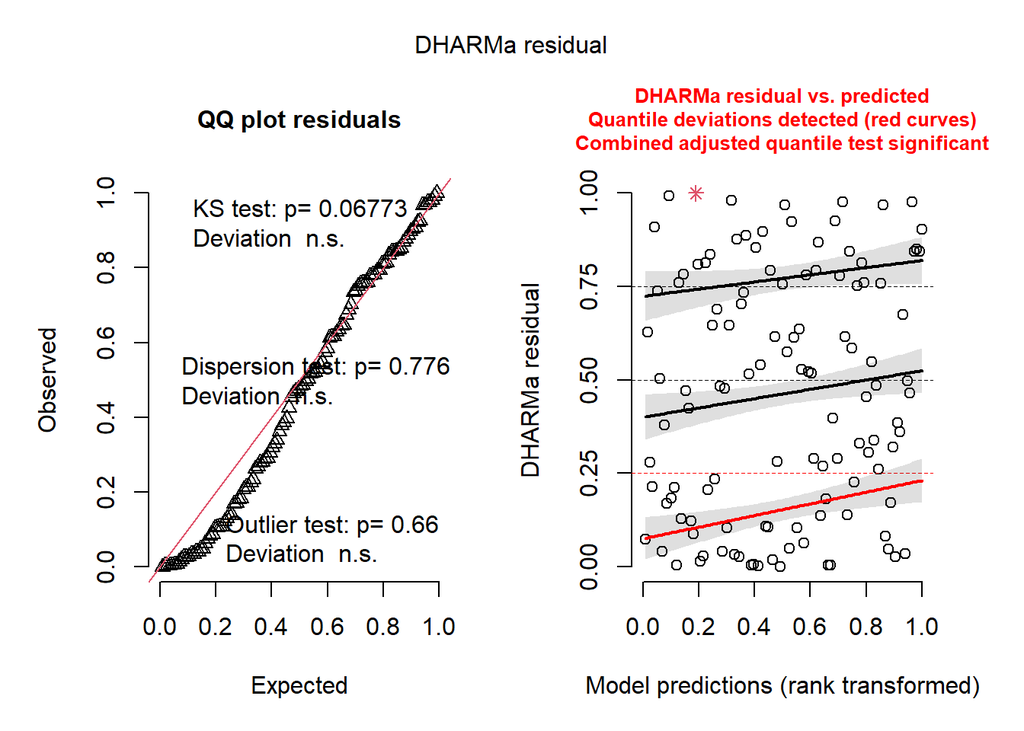

```r
residuals_carabid_abund <- simulateResiduals(carabid_abund_poisson)
plot(residuals_carabid_abund)
```

```r
# switch to negative binomial
carabid_abund_nb <- glmmTMB(
  carabid_abundance ~
    z_veg_height + z_veg_cover + z_veg_richness +
    z_total_natural_500 + z_distance_natural + year +
    (1 | site_ID) +
    offset(log(trap_count)),
  data = carabid_df_clean,
  family = nbinom1
)
```

##### 8.2.3.1 Meeting model assumptions

```r
# check residuals
summary(carabid_abund_nb)
```

```
##  Family: nbinom1  ( log )
## Formula:
## carabid_abundance ~ z_veg_height + z_veg_cover + z_veg_richness +
##     z_total_natural_500 + z_distance_natural + year + (1 | site_ID) +
##     offset(log(trap_count))
## Data: carabid_df_clean
##
##       AIC       BIC    logLik -2*log(L)  df.resid
##     740.9     765.7    -361.5     722.9       107
##
## Random effects:
##
## Conditional model:
##  Groups  Name        Variance Std.Dev.
##  site_ID (Intercept) 0.2459   0.4959
## Number of obs: 116, groups:  site_ID, 37
##
## Dispersion parameter for nbinom1 family (): 4.52
##
## Conditional model:
##                       Estimate Std. Error z value Pr(>|z|)
## (Intercept)          0.5628750  0.1847835   3.046  0.00232 **
## z_veg_height         0.2938820  0.0911465   3.224  0.00126 **
## z_veg_cover         -0.0003259  0.1069811  -0.003  0.99757
## z_veg_richness      -0.0539418  0.1036211  -0.521  0.60267
## z_total_natural_500 -0.0111282  0.1301761  -0.085  0.93187
## z_distance_natural   0.1491512  0.1327895   1.123  0.26135
## year2025             0.6062278  0.1921652   3.155  0.00161 **
## ---
## Signif. codes:  0 '***' 0.001 '**' 0.01 '*' 0.05 '.' 0.1 ' ' 1
```

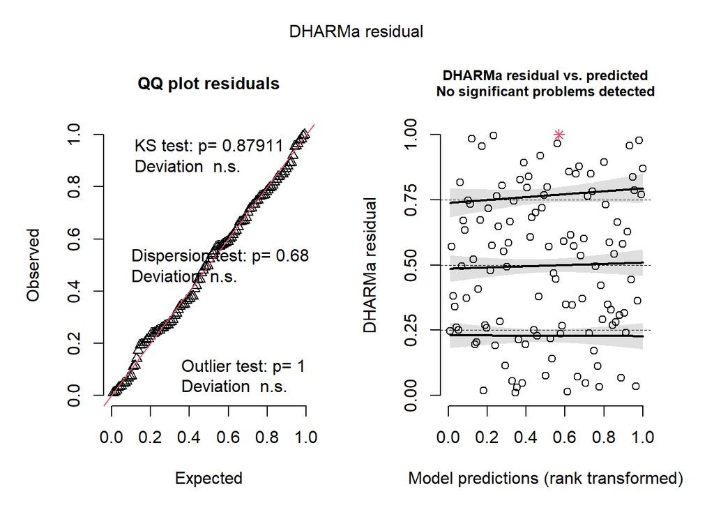

```r
residuals_carabid_abund <- simulateResiduals(carabid_abund_nb)
plot(residuals_carabid_abund)
```

##### 8.2.3.2 Model outputs

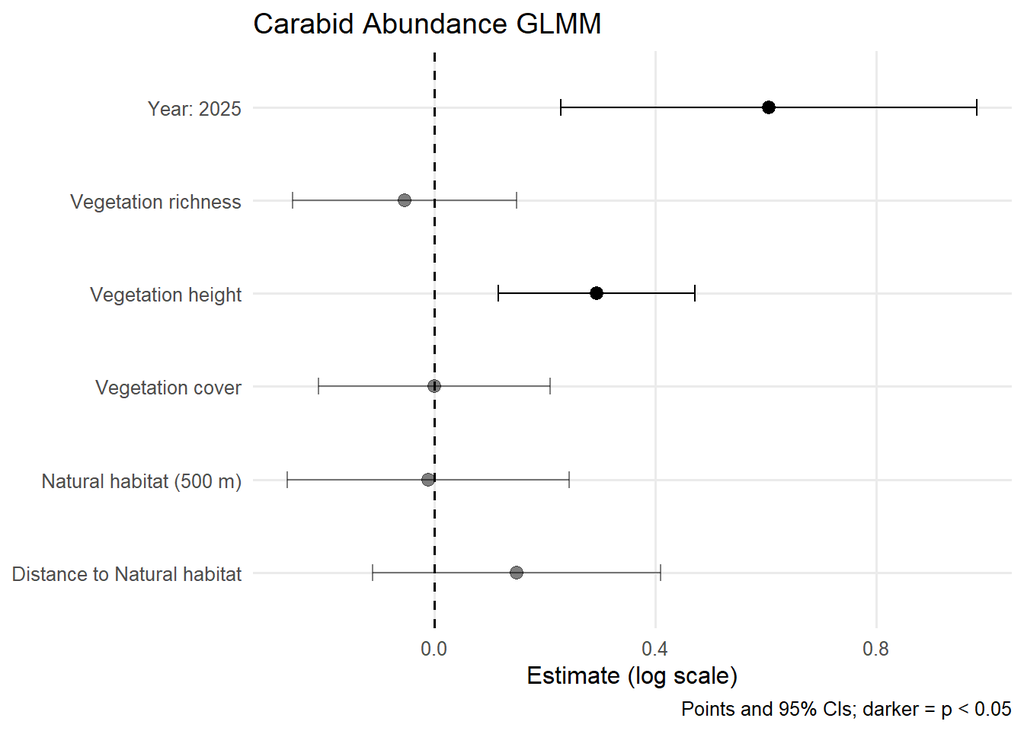

```r
# Tidy fixed effects with 95% CIs (log scale)
fx_carabid_abund <- tidy(carabid_abund_nb, effects = "fixed", conf.int = TRUE) %>%
  filter(term != "(Intercept)") %>%
  mutate(
    term_label = dplyr::recode(term,
                               "z_veg_height"         = "Vegetation height",
                               "z_veg_cover"          = "Vegetation cover",
                               "z_veg_richness"       = "Vegetation richness",
                               "z_total_natural_500"  = "Natural habitat (500 m)",
                               "z_distance_natural"  = "Distance to Natural habitat",
                               "year2025"             = "Year: 2025"
    ),
    sig = p.value < 0.05
  )


# plot GLMM model fixed effects
p_log_abund_carabid <- ggplot(fx_carabid_abund, aes(x = estimate, y = term_label)) +
  geom_vline(xintercept = 0, linetype = "dashed", linewidth = 0.6) +
  geom_errorbarh(aes(xmin = conf.low, xmax = conf.high,
                     alpha = ifelse(sig, 1, 0.5)), height = 0.18) +
  geom_point(aes(alpha = ifelse(sig, 1, 0.5)), size = 2.8) +
  scale_alpha_identity() +
  labs(x = "Estimate (log scale)", y = NULL,
       title = "Carabid Abundance GLMM",
       caption = "Points and 95% CIs; darker = p < 0.05") +
  theme_minimal(base_size = 12) +
  theme(panel.grid.minor = element_blank())

p_log_abund_carabid
```

##### 8.2.3.3 Sensitivity analysis: year

```r
# filter to only 2024 data
carabid_data_2024 <- carabid_df_clean %>%
  filter(year==2024)

# filter to only 2025 data
carabid_data_2025 <- carabid_df_clean %>%
  filter(year==2025)
```

```r
# model 2024 data
carabid_abund_2024 <- glmmTMB(
  carabid_abundance ~
    z_veg_height + z_veg_cover + z_veg_richness +
    z_total_natural_500 + z_distance_natural +
    (1 | site_ID) +
    offset(log(trap_count)),
  data = carabid_data_2024,
  family = poisson
)
summary(carabid_abund_2024)
```

```
##  Family: poisson  ( log )
## Formula:
## carabid_abundance ~ z_veg_height + z_veg_cover + z_veg_richness +
##     z_total_natural_500 + z_distance_natural + (1 | site_ID) +
##     offset(log(trap_count))
## Data: carabid_data_2024
##
##       AIC       BIC    logLik -2*log(L)  df.resid
##     218.8     231.0    -102.4     204.8        35
##
## Random effects:
##
## Conditional model:
##  Groups  Name        Variance Std.Dev.
##  site_ID (Intercept) 0.9588   0.9792
## Number of obs: 42, groups:  site_ID, 21
##
## Conditional model:
##                     Estimate Std. Error z value Pr(>|z|)
## (Intercept)          0.09168    0.26468   0.346  0.72907
## z_veg_height         0.82076    0.17123   4.793 1.64e-06 ***
## z_veg_cover          0.08410    0.16067   0.523  0.60068
## z_veg_richness      -0.51692    0.19518  -2.648  0.00809 **
## z_total_natural_500  0.61694    0.29049   2.124  0.03369 *
## z_distance_natural   0.48316    0.25859   1.868  0.06170 .
## ---
## Signif. codes:  0 '***' 0.001 '**' 0.01 '*' 0.05 '.' 0.1 ' ' 1
```

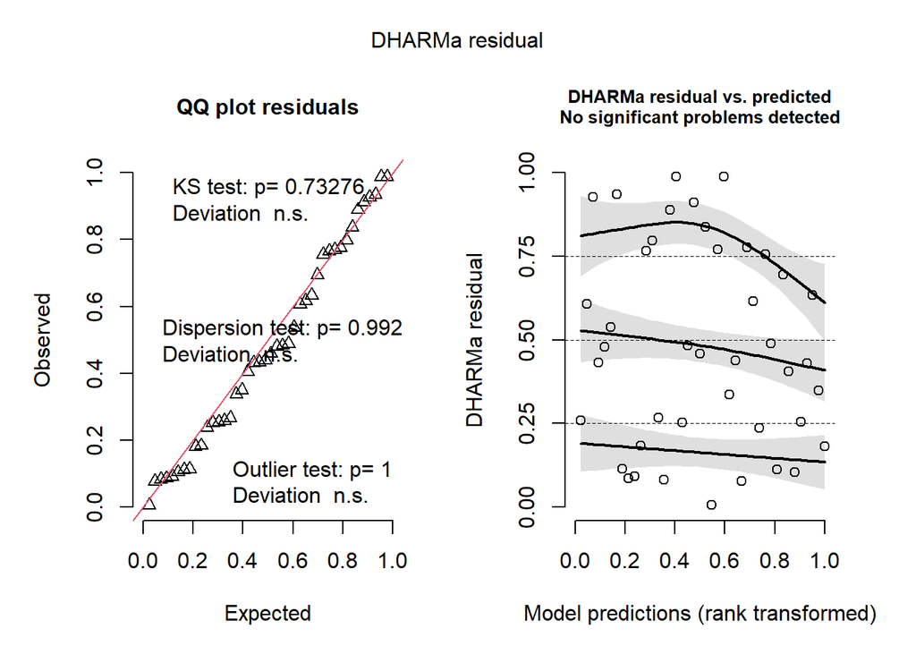

```r
residuals_2024 <- simulateResiduals(carabid_abund_2024)
plot(residuals_2024)
```

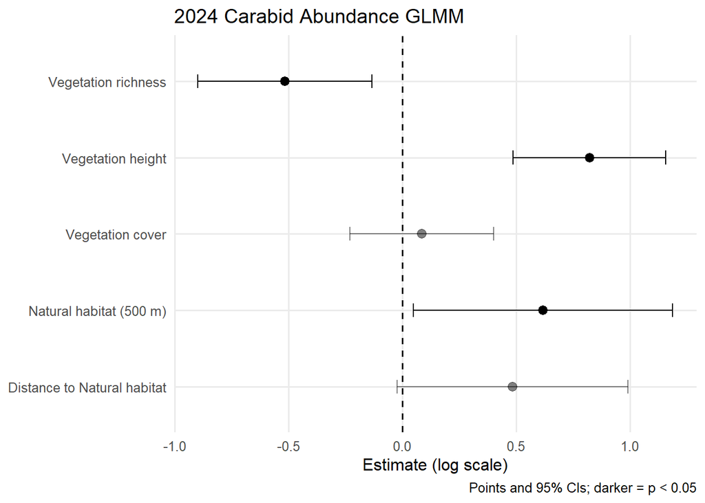

```r
# Tidy fixed effects with 95% CIs (log scale)
fx_abund_carabid_2024 <- tidy(carabid_abund_2024, effects = "fixed", conf.int = TRUE) %>%
  filter(term != "(Intercept)") %>%
  mutate(
    term_label = dplyr::recode(term,
                               "z_veg_height"         = "Vegetation height",
                               "z_veg_cover"          = "Vegetation cover",
                               "z_veg_richness"       = "Vegetation richness",
                               "z_total_natural_500"  = "Natural habitat (500 m)",
                               "z_distance_natural"  = "Distance to Natural habitat",
                               "year2025"             = "Year: 2025"
    ),
    sig = p.value < 0.05
  )



# plot GLMM model fixed effects
p_log_abund_carabid_2024 <- ggplot(fx_abund_carabid_2024, aes(x = estimate, y = term_label)) +
  geom_vline(xintercept = 0, linetype = "dashed", linewidth = 0.6) +
  geom_errorbarh(aes(xmin = conf.low, xmax = conf.high,
                     alpha = ifelse(sig, 1, 0.5)), height = 0.18) +
  geom_point(aes(alpha = ifelse(sig, 1, 0.5)), size = 2.8) +
  scale_alpha_identity() +
  labs(x = "Estimate (log scale)", y = NULL,
       title = "2024 Carabid Abundance GLMM",
       caption = "Points and 95% CIs; darker = p < 0.05") +
  theme_minimal(base_size = 12) +
  theme(panel.grid.minor = element_blank())

p_log_abund_carabid_2024
```

```r
# model 2025 data
carabid_abund_2025 <- glmmTMB(
  carabid_abundance ~
    z_veg_height + z_veg_cover + z_veg_richness +
    z_total_natural_500 + z_distance_natural +
    (1 | site_ID) +
    offset(log(trap_count)),
  data = carabid_data_2025,
  family = poisson
)
summary(carabid_abund_2025)
```

```
##  Family: poisson  ( log )
## Formula:
## carabid_abundance ~ z_veg_height + z_veg_cover + z_veg_richness +
##     z_total_natural_500 + z_distance_natural + (1 | site_ID) +
##     offset(log(trap_count))
## Data: carabid_data_2025
##
##       AIC       BIC    logLik -2*log(L)  df.resid
##     567.1     583.2    -276.5     553.1        67
##
## Random effects:
##
## Conditional model:
##  Groups  Name        Variance Std.Dev.
##  site_ID (Intercept) 0.7047   0.8394
## Number of obs: 74, groups:  site_ID, 37
##
## Conditional model:
##                     Estimate Std. Error z value Pr(>|z|)
## (Intercept)          0.95494    0.15039   6.350 2.16e-10 ***
## z_veg_height         0.28348    0.05726   4.951 7.38e-07 ***
## z_veg_cover         -0.22085    0.06907  -3.198  0.00139 **
## z_veg_richness       0.16763    0.07433   2.255  0.02412 *
## z_total_natural_500 -0.14354    0.17236  -0.833  0.40496
## z_distance_natural   0.11023    0.18181   0.606  0.54431
## ---
## Signif. codes:  0 '***' 0.001 '**' 0.01 '*' 0.05 '.' 0.1 ' ' 1
```

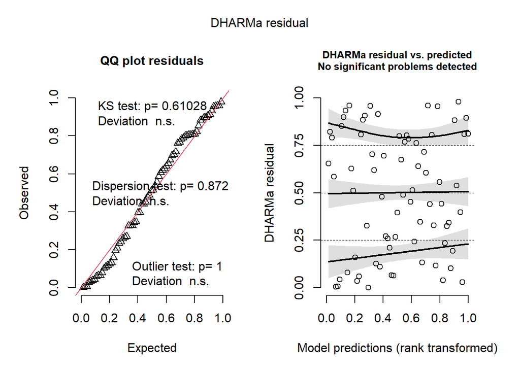

```r
residuals_2025 <- simulateResiduals(carabid_abund_2025)
plot(residuals_2025)
```

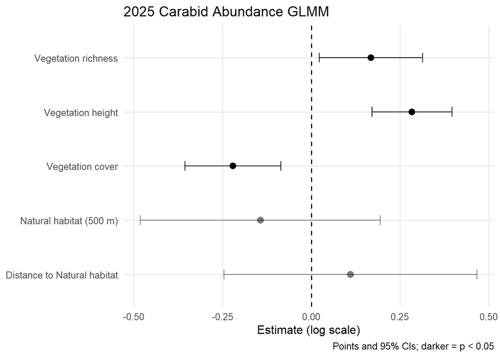

```r
# Tidy fixed effects with 95% CIs (log scale)
fx_abund_carabid_2025 <- tidy(carabid_abund_2025, effects = "fixed", conf.int = TRUE) %>%
  filter(term != "(Intercept)") %>%
  mutate(
    term_label = dplyr::recode(term,
                               "z_veg_height"         = "Vegetation height",
                               "z_veg_cover"          = "Vegetation cover",
                               "z_veg_richness"       = "Vegetation richness",
                               "z_total_natural_500"  = "Natural habitat (500 m)",
                               "z_distance_natural"  = "Distance to Natural habitat",
                               "year2025"             = "Year: 2025"
    ),
    sig = p.value < 0.05
  )

# plot GLMM model fixed effects
p_log_abund_carabid_2025 <- ggplot(fx_abund_carabid_2025, aes(x = estimate, y = term_label)) +
  geom_vline(xintercept = 0, linetype = "dashed", linewidth = 0.6) +
  geom_errorbarh(aes(xmin = conf.low, xmax = conf.high,
                     alpha = ifelse(sig, 1, 0.5)), height = 0.18) +
  geom_point(aes(alpha = ifelse(sig, 1, 0.5)), size = 2.8) +
  scale_alpha_identity() +
  labs(x = "Estimate (log scale)", y = NULL,
       title = "2025 Carabid Abundance GLMM",
       caption = "Points and 95% CIs; darker = p < 0.05") +
  theme_minimal(base_size = 12) +
  theme(panel.grid.minor = element_blank())

p_log_abund_carabid_2025
```

2024: veg richness negative effect, vegetation height and proportion natural habitat (500m) positive effect

2025: veg richness and height positive effect, cover negative

##### 8.2.3.4 Sensitivity analysis: landscape scale

```r
# Build a function to fit the model for a given natural-cover scale
carabid_abund_scale <- function(nat_col, data = carabid_df_clean) {

  # Create the formula programmatically so only nat_col changes
  f <- as.formula(paste(
    "carabid_abundance ~",
    "z_veg_height + z_veg_cover + z_veg_richness +",
    nat_col, "+ z_distance_natural + year +",
    "(1 | site_ID) + offset(log(trap_count))"
  ))

  glmmTMB(
    formula = f,
    data = data,
    family = nbinom1()
  )
}

# Fit all scales
carabid_abund_fit <- setNames(
  lapply(nat_cols, carabid_abund_scale),
  paste0(scales, "m")
)

# Compare model fit across scales (AIC)
carabid_abund_aic <- tibble(
  scale = names(carabid_abund_fit),
  AIC = sapply(carabid_abund_fit, AIC)
) %>%
  arrange(AIC) %>%
  mutate(delta_AIC = AIC - min(AIC))

carabid_abund_aic
```

| scale | AIC | delta_AIC |
| --- | --- | --- |
| 250m | 740.7007 | 0.00000000 |
| 100m | 740.7191 | 0.01838799 |
| 1000m | 740.8977 | 0.19700025 |
| 500m | 740.9082 | 0.20755293 |
| 750m | 740.9147 | 0.21402307 |

```r
# Extract the effect of "total natural" at each scale (estimate + CI)
# This pulls the coefficient that matches the nat_col used in each model.
carabid_abund_coef <- imap_dfr(carabid_abund_fit, function(mod, scale_nm){

  nat_term <- paste0("z_total_natural_", sub("m", "", scale_nm))

  broom.mixed::tidy(mod, effects = "fixed", conf.int = TRUE) %>%
    filter(term == nat_term) %>%
    mutate(scale = scale_nm) %>%
    select(scale, term, estimate, conf.low, conf.high, std.error, statistic, p.value)
})

carabid_abund_coef %>% arrange(as.numeric(sub("m","", scale)))
```

| scale | term | estimate | conf.low | conf.high | std.error | statistic | p.value |
| --- | --- | --- | --- | --- | --- | --- | --- |
| 100m | z_total_natural_100 | -0.054714978 | -0.2965815 | 0.1871515 | 0.1234035 | -0.44338256 | 0.6574890 |
| 250m | z_total_natural_250 | -0.058465073 | -0.3043778 | 0.1874476 | 0.1254680 | -0.46597605 | 0.6412326 |
| 500m | z_total_natural_500 | -0.011128249 | -0.2662688 | 0.2440123 | 0.1301761 | -0.08548610 | 0.9318749 |
| 750m | z_total_natural_750 | -0.003664549 | -0.2540330 | 0.2467039 | 0.1277413 | -0.02868726 | 0.9771140 |
| 1000m | z_total_natural_1000 | -0.016621093 | -0.2605441 | 0.2273019 | 0.1244528 | -0.13355338 | 0.8937558 |

Proportion of natural habitat not an important predictor at any scale. No difference between scales based on AIC (delta AIC <2)

#### 8.2.4 Carabid Species Richness

```r
# Fit GLMM model (using Poisson first, then check for overdispersion)
#Site as random effect
carabid_richness_poisson <- glmmTMB(
  species_richness ~ z_veg_height + z_veg_cover + z_veg_richness + z_total_natural_500 + z_distance_natural + year + (1 | site_ID) +
    offset(log(trap_count)),
  data = carabid_df_clean,
  family = "poisson",
  na.action = na.fail
)

summary(carabid_richness_poisson)
```

```
##  Family: poisson  ( log )
## Formula:
## species_richness ~ z_veg_height + z_veg_cover + z_veg_richness +
##     z_total_natural_500 + z_distance_natural + year + (1 | site_ID) +
##     offset(log(trap_count))
## Data: carabid_df_clean
##
##       AIC       BIC    logLik -2*log(L)  df.resid
##     438.4     460.5    -211.2     422.4       108
##
## Random effects:
##
## Conditional model:
##  Groups  Name        Variance Std.Dev.
##  site_ID (Intercept) 0.1355   0.3681
## Number of obs: 116, groups:  site_ID, 37
##
## Conditional model:
##                     Estimate Std. Error z value Pr(>|z|)
## (Intercept)         -0.34194    0.13794  -2.479   0.0132 *
## z_veg_height         0.09866    0.07685   1.284   0.1992
## z_veg_cover         -0.02158    0.08465  -0.255   0.7988
## z_veg_richness      -0.04226    0.08431  -0.501   0.6162
## z_total_natural_500  0.10695    0.10413   1.027   0.3044
## z_distance_natural   0.18126    0.10359   1.750   0.0802 .
## year2025             0.23384    0.15300   1.528   0.1264
## ---
## Signif. codes:  0 '***' 0.001 '**' 0.01 '*' 0.05 '.' 0.1 ' ' 1
```

##### 8.2.4.1 Meeting model assumptions

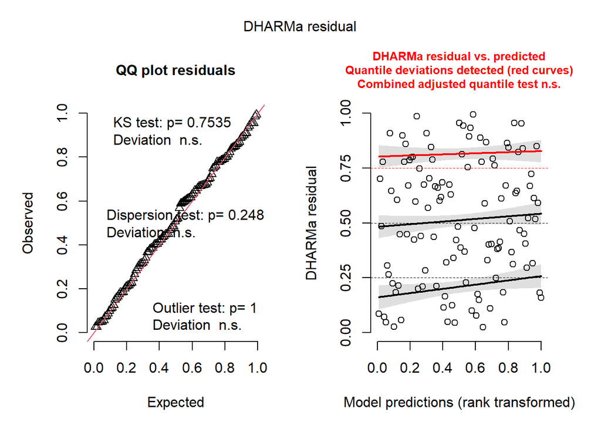

```r
# Check residuals
carabid_residuals_poisson <- DHARMa::simulateResiduals(carabid_richness_poisson)
plot(carabid_residuals_poisson)
```

```r
# Check performance (marginal and condition R-squared)
performance::r2(carabid_richness_poisson)
```

```
## # R2 for Mixed Models
##
##   Conditional R2: 0.195
##      Marginal R2: 0.048
```

Residuals look okay!

No evidence of influential outliers in residuals.

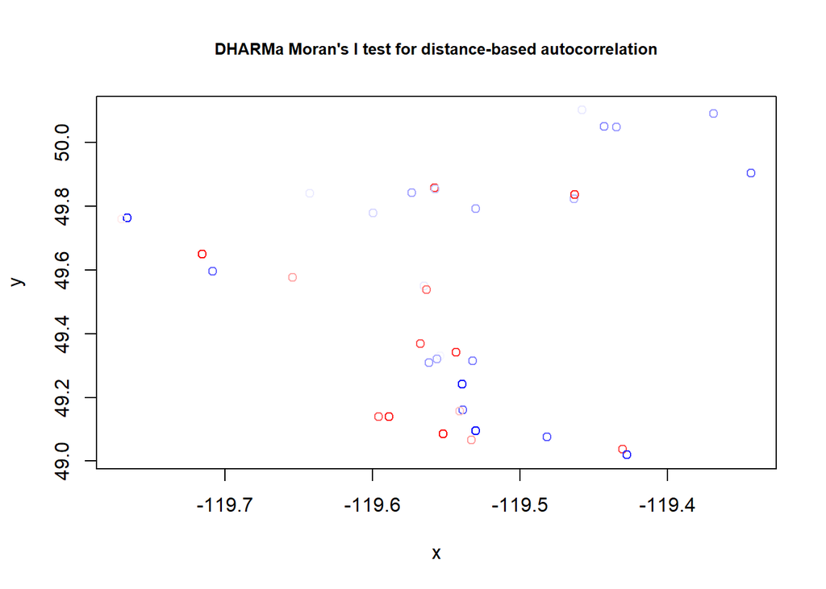

```
##
##  DHARMa Moran's I test for distance-based autocorrelation
##
## data:  sim_res_site_carabid_rich
## observed = -0.083589, expected = -0.027778, sd = 0.085283, p-value =
## 0.5128
## alternative hypothesis: Distance-based autocorrelation
```

```r
# Testing for spatial autocorrelation
# test using dharma
# Simulate DHARMa residuals
sim_res_carabid_rich <- simulateResiduals(carabid_richness_poisson, plot = FALSE)

# recalculate per site
sim_res_site_carabid_rich <- recalculateResiduals(sim_res_carabid_rich, group = data_dharma_carabids$site_ID)

# aggregate coordinates by site
coords_site_carabids <- data_dharma_carabids %>%
  group_by(site_ID) %>%
  summarise(
    long = first(long),
    lat  = first(lat),
    .groups = "drop"
  ) %>%
  arrange(site_ID)

# Spatial autocorrelation test (coords repeated for each observation at same site)
testSpatialAutocorrelation(
  sim_res_site_carabid_rich,
  x = coords_site_carabids$long,
  y = coords_site_carabids$lat
)
```

##### 8.2.4.2 Model outputs

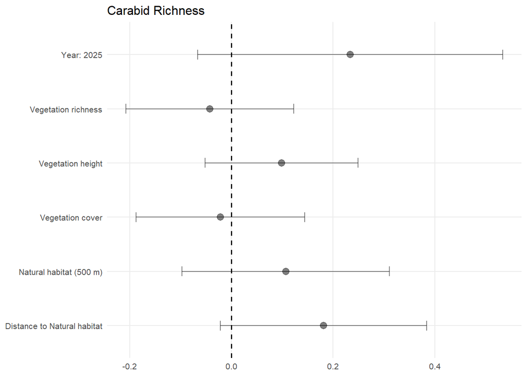

```r
# Tidy fixed effects with 95% CIs (log scale)
fx_carabid_richness <- tidy(carabid_richness_poisson, effects = "fixed", conf.int = TRUE) %>%
  filter(term != "(Intercept)") %>%
  mutate(
    term_label = dplyr::recode(term,
                               "z_veg_height"         = "Vegetation height",
                               "z_veg_cover"          = "Vegetation cover",
                               "z_veg_richness"       = "Vegetation richness",
                               "z_total_natural_500"  = "Natural habitat (500 m)",
                               "z_distance_natural"  = "Distance to Natural habitat",
                               "year2025"             = "Year: 2025"
    ),
    sig = p.value < 0.05
  )

# plot GLMM model fixed effects
p_log_carabid_richness <- ggplot(fx_carabid_richness, aes(x = estimate, y = term_label)) +
  geom_vline(xintercept = 0, linetype = "dashed", linewidth = 0.6) +
  geom_errorbarh(aes(xmin = conf.low, xmax = conf.high,
                     alpha = ifelse(sig, 1, 0.5)), height = 0.18) +
  geom_point(aes(alpha = ifelse(sig, 1, 0.5)), size = 2.8) +
  scale_alpha_identity() +
  labs(x = NULL, y = NULL,
       title = "Carabid Richness") +
  theme_minimal(base_size = 10) +
  theme(panel.grid.minor = element_blank()
        )

p_log_carabid_richness
```

No significant predictors for carabid richness, all confidence intervals cross 0.

##### 8.2.4.3 Sensitivity analysis: landscape scale

```r
# Build a function to fit the model for a given natural-cover scale
carabid_richness_scale <- function(nat_col, data = carabid_df_clean) {

  # Create the formula programmatically so only nat_col changes
  f <- as.formula(paste(
    "species_richness ~",
    "z_veg_height + z_veg_cover + z_veg_richness +",
    nat_col, "+ z_distance_natural + year +",
    "(1 | site_ID) + offset(log(trap_count))"
  ))

  glmmTMB(
    formula = f,
    data = data,
    family = poisson()
  )
}

# Fit all scales
carabid_richness_fit <- setNames(
  lapply(nat_cols, carabid_richness_scale),
  paste0(scales, "m")
)

# Compare model fit across scales (AIC)
carabid_richness_aic <- tibble(
  scale = names(carabid_richness_fit),
  AIC = sapply(carabid_richness_fit, AIC)
) %>%
  arrange(AIC) %>%
  mutate(delta_AIC = AIC - min(AIC))

carabid_richness_aic
```

| scale | AIC | delta_AIC |
| --- | --- | --- |
| 500m | 438.4253 | 0.0000000 |
| 750m | 438.5565 | 0.1312034 |
| 1000m | 438.9612 | 0.5358461 |
| 250m | 439.2480 | 0.8226343 |
| 100m | 439.4546 | 1.0293037 |

```r
# Extract the effect of "total natural" at each scale (estimate + CI)
# This pulls the coefficient that matches the nat_col used in each model.
carabid_richness_coef <- imap_dfr(carabid_richness_fit, function(mod, scale_nm){

  nat_term <- paste0("z_total_natural_", sub("m", "", scale_nm))

  broom.mixed::tidy(mod, effects = "fixed", conf.int = TRUE) %>%
    filter(term == nat_term) %>%
    mutate(scale = scale_nm) %>%
    select(scale, term, estimate, conf.low, conf.high, std.error, statistic, p.value)
})

carabid_richness_coef %>% arrange(as.numeric(sub("m","", scale)))
```

| scale | term | estimate | conf.low | conf.high | std.error | statistic | p.value |
| --- | --- | --- | --- | --- | --- | --- | --- |
| 100m | z_total_natural_100 | 0.001031645 | -0.20142389 | 0.2034872 | 0.10329554 | 0.009987318 | 0.9920314 |
| 250m | z_total_natural_250 | 0.047254634 | -0.15545857 | 0.2499678 | 0.10342701 | 0.456888735 | 0.6477510 |
| 500m | z_total_natural_500 | 0.106950643 | -0.09713829 | 0.3110396 | 0.10412892 | 1.027098341 | 0.3043742 |
| 750m | z_total_natural_750 | 0.097797792 | -0.10206038 | 0.2976560 | 0.10197033 | 0.959080864 | 0.3375180 |
| 1000m | z_total_natural_1000 | 0.070662600 | -0.12495369 | 0.2662789 | 0.09980606 | 0.707999063 | 0.4789458 |

Not sifnigicant at any scale.

### 8.3 Model Summaries and Outputs

Output table for GLMM model results

#### 8.3.1 Management

```r
# helper function
tidy_glmm <- function(model, response_label) {
  tidy(model, effects = "fixed") %>%
    # drop intercept or keep it; here we keep it and give a label
    dplyr::mutate(
      Predictor = dplyr::recode(
        term,
        "management_typeorg"  = "Management: Organic",
        "habitatDR"           = "Inter-row habitat",
        "year2025"            = "Year (2025)",   # if present
        .default = term       #
      ),
      Response = response_label
    ) %>%
    dplyr::select(Response, Predictor, estimate, std.error, statistic, p.value)
}

# create table for each response variable
tab_spider_abund_mgmt   <- tidy_glmm(spider_abund_mgmt_nb,   "Spider abundance")
tab_spider_rich_mgmt    <- tidy_glmm(spider_richness_mgmt_compois,    "Spider family richness")
tab_carabid_abund_mgmt  <- tidy_glmm(carabid_abund_mgmt_nb,  "Carabid abundance")
tab_carabid_rich_mgmt   <- tidy_glmm(carabid_richness_mgmt_poisson,   "Carabid species richness")

# combine tables
model_results_mgmt <- bind_rows(
  tab_spider_rich_mgmt,
  tab_spider_abund_mgmt,
  tab_carabid_rich_mgmt,
  tab_carabid_abund_mgmt
)

# clean up numbers
model_results_mgmt_clean <- model_results_mgmt %>%
  dplyr::mutate(
    Estimate = round(estimate, 2),
    SE       = round(std.error, 2),
    z        = round(statistic, 2),
    p_raw    = p.value,
    p        = case_when(
      p_raw < 0.001 ~ "< 0.001",
      TRUE          ~ sprintf("%.3f", p_raw)
    )
  ) %>%
  dplyr::select(Response, Predictor, Estimate, SE, z, p) %>%
  arrange(Response, Predictor)

# save as table
write.csv(
  model_results_mgmt_clean,
  here::here("02_tables", "model_results_mgmt_clean.csv"),
  row.names = FALSE
)

# get group indices
kable(
  model_results_mgmt_clean,
  col.names = c("Response variable", "Predictors", "Estimate", "SE", "z", "p"),
  align    = "llrrrr",
  booktabs = TRUE,
  caption  = "GLMM results for spider and carabid responses.",
  escape   = FALSE        # important for bold p-values
) %>%
  kable_styling(full_width = FALSE) %>%
  collapse_rows(columns = 1, valign = "top")
```

GLMM results for spider and carabid responses.

| Response variable | Predictors | Estimate | SE | z | p |
| --- | --- | --- | --- | --- | --- |
| Carabid abundance | (Intercept) | 0.47 | 0.23 | 2.08 | 0.037 |
|  | Inter-row habitat | -0.28 | 0.13 | -2.13 | 0.033 |
|  | Management: Organic | 0.30 | 0.25 | 1.17 | 0.243 |
|  | Year (2025) | 0.73 | 0.17 | 4.33 | < 0.001 |
| Carabid species richness | (Intercept) | -0.22 | 0.16 | -1.38 | 0.167 |
|  | Inter-row habitat | -0.16 | 0.11 | -1.36 | 0.174 |
|  | Management: Organic | -0.15 | 0.18 | -0.79 | 0.427 |
|  | Year (2025) | 0.25 | 0.13 | 1.91 | 0.056 |
| Spider abundance | (Intercept) | -615.30 | 209.01 | -2.94 | 0.003 |
|  | Inter-row habitat | -0.03 | 0.08 | -0.34 | 0.733 |
|  | Management: Organic | 0.81 | 0.19 | 4.37 | < 0.001 |
|  | year | 0.31 | 0.10 | 2.95 | 0.003 |
| Spider family richness | (Intercept) | -513.54 | 114.99 | -4.47 | < 0.001 |
|  | Inter-row habitat | -0.06 | 0.05 | -1.25 | 0.211 |
|  | Management: Organic | 0.17 | 0.06 | 3.07 | 0.002 |
|  | year | 0.25 | 0.06 | 4.47 | < 0.001 |

And a final figure for GLMM model results

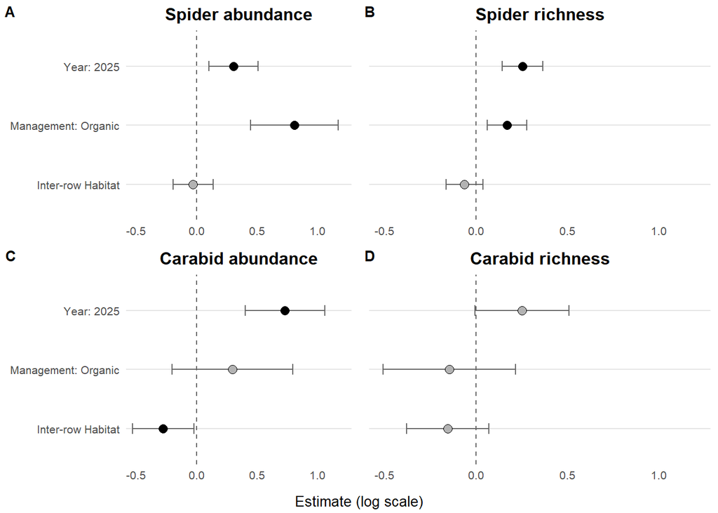

```r
# labels for predictor variables
predictor_levels <- c(
  "Year: 2025",
  "Management: Organic",
  "Inter-row Habitat"
)

# specify plot parameters
make_effect_plot <- function(fx, panel_title, xlim = c(-0.5, 1.2), show_y_labels = TRUE) {

  fx <- fx %>%
    mutate(
      term_label = factor(term_label, levels = rev(predictor_levels)),
      col = ifelse(sig, "sig", "nonsig")
    )

  p <- ggplot(fx, aes(x = estimate, y = term_label)) +
    geom_vline(xintercept = 0, linetype = 2, linewidth = 0.5, colour = "grey40") +
    geom_errorbarh(aes(xmin = conf.low, xmax = conf.high),
                   height = 0.18, linewidth = 0.4, colour = "grey40") +
    geom_point(aes(fill = col), shape = 21, size = 2.8, stroke = 0.3) +
    scale_fill_manual(values = c(sig = "black", nonsig = "grey70"), guide = "none") +
    coord_cartesian(xlim = xlim) +
    labs(x = NULL, y = NULL, title = panel_title) +
    theme_minimal(base_size = 10) +
    theme(
      panel.grid.major.x = element_blank(),
      panel.grid.minor = element_blank(),
      panel.grid.major.y = element_line(colour = "grey90"),
      plot.title = element_text(hjust = 0.5, face = "bold"),
      axis.text.x = element_text(size = 8)
    )

  if (!show_y_labels) {
    p <- p + theme(axis.text.y = element_blank(),
                   axis.ticks.y = element_blank())
  }

  return(p)
}

# make plot for each response variable
# only show the y axis labels for figures on the left
pA <- make_effect_plot(fx_spider_abund_mgmt,     "Spider abundance",       show_y_labels = TRUE)
pB <- make_effect_plot(fx_spider_richness_mgmt,      "Spider richness",        show_y_labels = FALSE)
pC <- make_effect_plot(fx_carabid_abund_mgmt,    "Carabid abundance",      show_y_labels = TRUE)
pD <- make_effect_plot(fx_carabid_richness_mgmt, "Carabid richness",       show_y_labels = FALSE)


# combine model output figures
p_log_all <- cowplot::plot_grid(
  pA, pB,
  pC, pD,
  labels = c("A", "B", "C", "D"),
  label_size = 10,
  ncol = 2
)

# add x axis label at the bottom
final_model_output <- cowplot::plot_grid(
  p_log_all,
  ggdraw() + draw_label("Estimate (log scale)", size = 10),
  ncol = 1,
  rel_heights = c(1, 0.05)
)

final_model_output
```

```r
# save to figures folder
ggsave(
  filename = here::here("03_figures", "final_mgmt_output.png"),
  plot = final_model_output,
  width = 7,
  height = 5,
  dpi = 300       # high-resolution
)
```

#### 8.3.2 Local and landscape factors

```r
# create function to make model
tidy_glmm <- function(model, response_label) {
  tidy(model, effects = "fixed") %>%
    # drop intercept or keep it; here we keep it and give a label
    dplyr::mutate(
      Predictor = dplyr::recode(
        term,
                              "z_veg_height"         = "Vegetation height",
                               "z_veg_cover"          = "Vegetation cover",
                               "z_veg_richness"       = "Vegetation richness",
                               "z_total_natural_500"  = "Natural habitat (500 m)",
                               "z_distance_natural"  = "Distance to Natural habitat",
                               "year2025"             = "Year: 2025",
        .default = term       #
      ),
      Response = response_label
    ) %>%
    dplyr::select(Response, Predictor, estimate, std.error, statistic, p.value)
}

# create table for each response variable
tab_spider_abund   <- tidy_glmm(spider_abund_nb,   "Spider abundance")
tab_spider_rich    <- tidy_glmm(spider_richness_compois,    "Spider family richness")
tab_carabid_abund  <- tidy_glmm(carabid_abund_nb,  "Carabid abundance")
tab_carabid_rich   <- tidy_glmm(carabid_richness_poisson,   "Carabid species richness")

# combine tables
model_results_all <- bind_rows(
  tab_spider_rich,
  tab_spider_abund,
  tab_carabid_rich,
  tab_carabid_abund
)

# clean up numbers
model_results_clean <- model_results_all %>%
  dplyr::mutate(
    Estimate = round(estimate, 2),
    SE       = round(std.error, 2),
    z        = round(statistic, 2),
    p_raw    = p.value,
    p        = case_when(
      p_raw < 0.001 ~ "< 0.001",
      TRUE          ~ sprintf("%.3f", p_raw)
    )
  ) %>%
  dplyr::select(Response, Predictor, Estimate, SE, z, p) %>%
  arrange(Response, Predictor)

# save as table
write.csv(
  model_results_clean,
  here::here("02_tables", "LL_model_results_clean.csv"),
  row.names = FALSE
)

# get group indices
kable(
  model_results_clean,
  col.names = c("Response variable", "Predictors", "Estimate", "SE", "z", "p"),
  align    = "llrrrr",
  booktabs = TRUE,
  caption  = "GLMM results for spider and carabid responses.",
  escape   = FALSE        # important for bold p-values
) %>%
  kable_styling(full_width = FALSE) %>%
  collapse_rows(columns = 1, valign = "top")
```

GLMM results for spider and carabid responses.

| Response variable | Predictors | Estimate | SE | z | p |
| --- | --- | --- | --- | --- | --- |
| Carabid abundance | (Intercept) | 0.56 | 0.18 | 3.05 | 0.002 |
|  | Distance to Natural habitat | 0.15 | 0.13 | 1.12 | 0.261 |
|  | Natural habitat (500 m) | -0.01 | 0.13 | -0.09 | 0.932 |
|  | Vegetation cover | 0.00 | 0.11 | 0.00 | 0.998 |
|  | Vegetation height | 0.29 | 0.09 | 3.22 | 0.001 |
|  | Vegetation richness | -0.05 | 0.10 | -0.52 | 0.603 |
|  | Year: 2025 | 0.61 | 0.19 | 3.15 | 0.002 |
| Carabid species richness | (Intercept) | -0.34 | 0.14 | -2.48 | 0.013 |
|  | Distance to Natural habitat | 0.18 | 0.10 | 1.75 | 0.080 |
|  | Natural habitat (500 m) | 0.11 | 0.10 | 1.03 | 0.304 |
|  | Vegetation cover | -0.02 | 0.08 | -0.25 | 0.799 |
|  | Vegetation height | 0.10 | 0.08 | 1.28 | 0.199 |
|  | Vegetation richness | -0.04 | 0.08 | -0.50 | 0.616 |
|  | Year: 2025 | 0.23 | 0.15 | 1.53 | 0.126 |
| Spider abundance | (Intercept) | -645.42 | 250.85 | -2.57 | 0.010 |
|  | Distance to Natural habitat | 0.16 | 0.13 | 1.16 | 0.246 |
|  | Natural habitat (500 m) | -0.04 | 0.13 | -0.29 | 0.774 |
|  | Vegetation cover | 0.10 | 0.08 | 1.26 | 0.207 |
|  | Vegetation height | 0.15 | 0.07 | 2.00 | 0.045 |
|  | Vegetation richness | 0.01 | 0.07 | 0.13 | 0.900 |
|  | year | 0.32 | 0.12 | 2.58 | 0.010 |
| Spider family richness | (Intercept) | -554.08 | 134.52 | -4.12 | < 0.001 |
|  | Distance to Natural habitat | -0.02 | 0.03 | -0.52 | 0.604 |
|  | Natural habitat (500 m) | -0.03 | 0.03 | -0.78 | 0.436 |
|  | Vegetation cover | 0.04 | 0.03 | 1.06 | 0.289 |
|  | Vegetation height | 0.04 | 0.03 | 1.44 | 0.149 |
|  | Vegetation richness | -0.07 | 0.03 | -1.99 | 0.046 |
|  | year | 0.27 | 0.07 | 4.12 | < 0.001 |

And a final figure for GLMM model results

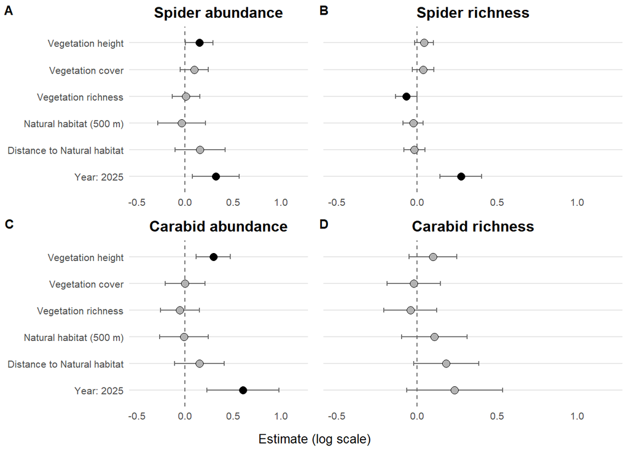

```r
# labels for predictor variables
predictor_levels <- c(
                                "z_veg_height"         = "Vegetation height",
                               "z_veg_cover"          = "Vegetation cover",
                               "z_veg_richness"       = "Vegetation richness",
                               "z_total_natural_500"  = "Natural habitat (500 m)",
                               "z_distance_natural"  = "Distance to Natural habitat",
                               "year2025"             = "Year: 2025"
)

# specify plot parameters
make_effect_plot <- function(fx, panel_title, xlim = c(-0.5, 1.2), show_y_labels = TRUE) {

  fx <- fx %>%
    mutate(
      term_label = factor(term_label, levels = rev(predictor_levels)),
      col = ifelse(sig, "sig", "nonsig")
    )

  p <- ggplot(fx, aes(x = estimate, y = term_label)) +
    geom_vline(xintercept = 0, linetype = 2, linewidth = 0.5, colour = "grey40") +
    geom_errorbarh(aes(xmin = conf.low, xmax = conf.high),
                   height = 0.18, linewidth = 0.4, colour = "grey40") +
    geom_point(aes(fill = col), shape = 21, size = 2.8, stroke = 0.3) +
    scale_fill_manual(values = c(sig = "black", nonsig = "grey70"), guide = "none") +
    coord_cartesian(xlim = xlim) +
    labs(x = NULL, y = NULL, title = panel_title) +
    theme_minimal(base_size = 10) +
    theme(
      panel.grid.major.x = element_blank(),
      panel.grid.minor = element_blank(),
      panel.grid.major.y = element_line(colour = "grey90"),
      plot.title = element_text(hjust = 0.5, face = "bold"),
      axis.text.x = element_text(size = 8)
    )

  if (!show_y_labels) {
    p <- p + theme(axis.text.y = element_blank(),
                   axis.ticks.y = element_blank())
  }

  return(p)
}

# make plot for each response variable
# only show the y axis labels for figures on the left
pA <- make_effect_plot(fx_spider_abund,     "Spider abundance",       show_y_labels = TRUE)
pB <- make_effect_plot(fx_spider_richness,      "Spider richness",        show_y_labels = FALSE)
pC <- make_effect_plot(fx_carabid_abund,    "Carabid abundance",      show_y_labels = TRUE)
pD <- make_effect_plot(fx_carabid_richness, "Carabid richness",       show_y_labels = FALSE)


# combine model output figures
p_log_all <- cowplot::plot_grid(
  pA, pB,
  pC, pD,
  labels = c("A", "B", "C", "D"),
  label_size = 10,
  ncol = 2
)

# add x axis label at the bottom
LL_model_output <- cowplot::plot_grid(
  p_log_all,
  ggdraw() + draw_label("Estimate (log scale)", size = 10),
  ncol = 1,
  rel_heights = c(1, 0.05)
)

LL_model_output
```

```r
# save to figures folder
ggsave(
  filename = here::here("03_figures", "LL_model_output.png"),
  plot = LL_model_output,
  width = 7,
  height = 6,
  dpi = 300       # high-resolution
)
```

#### 8.3.3 Inter-annual variation

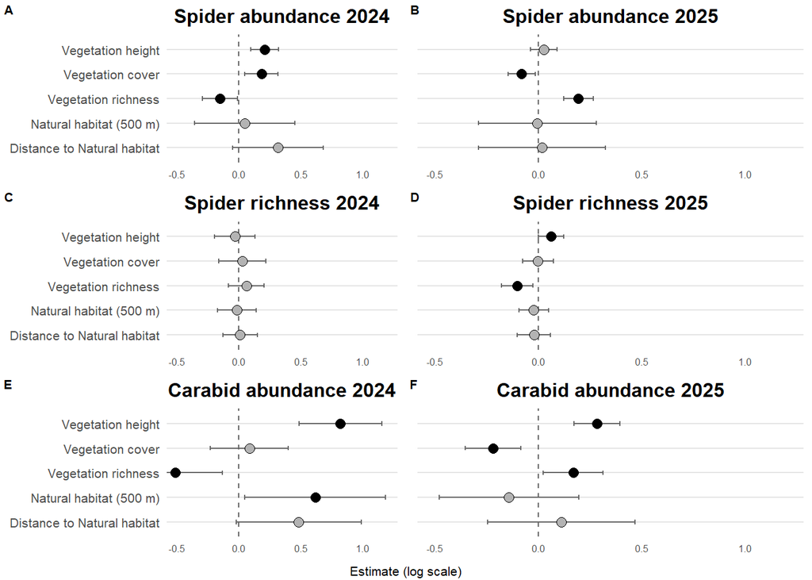

```r
# labels for predictor variables
predictor_levels <- c(
                                "z_veg_height"         = "Vegetation height",
                               "z_veg_cover"          = "Vegetation cover",
                               "z_veg_richness"       = "Vegetation richness",
                               "z_total_natural_500"  = "Natural habitat (500 m)",
                               "z_distance_natural"  = "Distance to Natural habitat",
                               "year2025"             = "Year: 2025"
)

# specify plot parameters
make_effect_plot <- function(fx, panel_title, xlim = c(-0.5, 1.2), show_y_labels = TRUE) {

  fx <- fx %>%
    mutate(
      term_label = factor(term_label, levels = rev(predictor_levels)),
      col = ifelse(sig, "sig", "nonsig")
    )

  p <- ggplot(fx, aes(x = estimate, y = term_label)) +
    geom_vline(xintercept = 0, linetype = 2, linewidth = 0.5, colour = "grey40") +
    geom_errorbarh(aes(xmin = conf.low, xmax = conf.high),
                   height = 0.18, linewidth = 0.4, colour = "grey40") +
    geom_point(aes(fill = col), shape = 21, size = 2.8, stroke = 0.3) +
    scale_fill_manual(values = c(sig = "black", nonsig = "grey70"), guide = "none") +
    coord_cartesian(xlim = xlim) +
    labs(x = NULL, y = NULL, title = panel_title) +
    theme_minimal(base_size = 10) +
    theme(
      panel.grid.major.x = element_blank(),
      panel.grid.minor = element_blank(),
      panel.grid.major.y = element_line(colour = "grey90"),
      plot.title = element_text(hjust = 0.5, face = "bold"),
      axis.text.x = element_text(size = 6)
    )

  if (!show_y_labels) {
    p <- p + theme(axis.text.y = element_blank(),
                   axis.ticks.y = element_blank())
  }

  return(p)
}

# make plot for each response variable
# only show the y axis labels for figures on the left
pA <- make_effect_plot(fx_abund_spider_2024,     "Spider abundance 2024",       show_y_labels = TRUE)
pB <- make_effect_plot(fx_abund_spider_2025,      "Spider abundance 2025",        show_y_labels = FALSE)
pC <- make_effect_plot(fx_richness_spider_2024,     "Spider richness 2024",       show_y_labels = TRUE)
pD <- make_effect_plot(fx_richness_spider_2025,      "Spider richness 2025",        show_y_labels = FALSE)
pE <- make_effect_plot(fx_abund_carabid_2024,    "Carabid abundance 2024",      show_y_labels = TRUE)
pF <- make_effect_plot(fx_abund_carabid_2025, "Carabid abundance 2025",       show_y_labels = FALSE)


# combine model output figures
p_log_all <- cowplot::plot_grid(
  pA, pB,
  pC, pD,
  pE, pF,
  labels = c("A", "B", "C", "D", "E", "F"),
  label_size = 8,
  ncol = 2
)

# add x axis label at the bottom
final_model_output_year <- cowplot::plot_grid(
  p_log_all,
  ggdraw() + draw_label("Estimate (log scale)", size = 8),
  ncol = 1,
  rel_heights = c(1.5, 0.05)
)

final_model_output_year
```

Make a table showing the model outputs for response variables modelled independently by year

```r
# create table for each response variable
tab_spider_abund_2024   <- tidy_glmm(spider_abund_2024,   "Spider abundance 2024")
tab_spider_abund_2025   <- tidy_glmm(spider_abund_2025,    "Spider abundance 2025")
tab_carabid_abund_2024  <- tidy_glmm(carabid_abund_2024,  "Carabid abundance 2024")
tab_carabid_abund_2025   <- tidy_glmm(carabid_abund_2025,   "Carabid abundance 2025")

# combine tables
model_results_years <- bind_rows(
  tab_spider_abund_2024,
  tab_spider_abund_2025,
  tab_carabid_abund_2024,
  tab_carabid_abund_2025
)

# clean up numbers
model_results_years_clean <- model_results_years %>%
  dplyr::mutate(
    Estimate = round(estimate, 2),
    SE       = round(std.error, 2),
    z        = round(statistic, 2),
    p_raw    = p.value,
    p        = case_when(
      p_raw < 0.001 ~ "< 0.001",
      TRUE          ~ sprintf("%.3f", p_raw)
    )
  ) %>%
  dplyr::select(Response, Predictor, Estimate, SE, z, p) %>%
  arrange(Response, Predictor)

# save as table
write.csv(
  model_results_years_clean,
  here::here("02_tables", "model_results_years_clean.csv"),
  row.names = FALSE
)


# get group indices
kable(
  model_results_years_clean,
  col.names = c("Response variable", "Predictors", "Estimate", "SE", "z", "p"),
  align    = "llrrrr",
  booktabs = TRUE,
  caption  = "GLMM results for spider and carabid responses.",
  escape   = FALSE        # important for bold p-values
) %>%
  kable_styling(full_width = FALSE) %>%
  collapse_rows(columns = 1, valign = "top")
```

GLMM results for spider and carabid responses.

| Response variable | Predictors | Estimate | SE | z | p |
| --- | --- | --- | --- | --- | --- |
| Carabid abundance 2024 | (Intercept) | 0.09 | 0.26 | 0.35 | 0.729 |
|  | Distance to Natural habitat | 0.48 | 0.26 | 1.87 | 0.062 |
|  | Natural habitat (500 m) | 0.62 | 0.29 | 2.12 | 0.034 |
|  | Vegetation cover | 0.08 | 0.16 | 0.52 | 0.601 |
|  | Vegetation height | 0.82 | 0.17 | 4.79 | < 0.001 |
|  | Vegetation richness | -0.52 | 0.20 | -2.65 | 0.008 |
| Carabid abundance 2025 | (Intercept) | 0.95 | 0.15 | 6.35 | < 0.001 |
|  | Distance to Natural habitat | 0.11 | 0.18 | 0.61 | 0.544 |
|  | Natural habitat (500 m) | -0.14 | 0.17 | -0.83 | 0.405 |
|  | Vegetation cover | -0.22 | 0.07 | -3.20 | 0.001 |
|  | Vegetation height | 0.28 | 0.06 | 4.95 | < 0.001 |
|  | Vegetation richness | 0.17 | 0.07 | 2.26 | 0.024 |
| Spider abundance 2024 | (Intercept) | 2.19 | 0.18 | 12.14 | < 0.001 |
|  | Distance to Natural habitat | 0.32 | 0.19 | 1.70 | 0.090 |
|  | Natural habitat (500 m) | 0.04 | 0.21 | 0.22 | 0.829 |
|  | Vegetation cover | 0.18 | 0.07 | 2.60 | 0.009 |
|  | Vegetation height | 0.21 | 0.06 | 3.68 | < 0.001 |
|  | Vegetation richness | -0.15 | 0.07 | -2.13 | 0.033 |
| Spider abundance 2025 | (Intercept) | 2.56 | 0.13 | 20.30 | < 0.001 |
|  | Distance to Natural habitat | 0.02 | 0.16 | 0.11 | 0.913 |
|  | Natural habitat (500 m) | -0.01 | 0.15 | -0.04 | 0.966 |
|  | Vegetation cover | -0.08 | 0.03 | -2.44 | 0.015 |
|  | Vegetation height | 0.03 | 0.03 | 0.80 | 0.425 |
|  | Vegetation richness | 0.19 | 0.04 | 5.38 | < 0.001 |